# Module used in this project

```python
import numpy as np
import pandas as pd
import matplotlib.pyplot as plt
import seaborn as sns
from mpl_toolkits import mplot3d
from sklearn.cluster import KMeans
from sklearn.cluster import AgglomerativeClustering
from sklearn import metrics
import numpy as np
```

# Dealing with Data 1

## uploading the files

```python
from google.colab import files
files.upload()
```

Upload widget is only available when the cell has been executed in the current browser session. Please rerun this cell to enable.

```
Saving Data1.csv to Data1.csv
```

[output not shown]

```python
df_sub1 = pd.read_csv(r'Data1.csv').iloc[:,1:]
```

## exploring about the data

```python
df_sub1.shape
```

```
(212, 4)
```

```python
df_sub1.head(2)
```

|  | X1 | X2 | X3 | Class |
| --- | --- | --- | --- | --- |
| 0 | -0.063274 | 0.027734 | 0.022683 | 1 |
| 1 | -0.000731 | 0.048211 | 0.069198 | 1 |

```python
df_sub1['Class'].value_counts()
```

```
1    32
2    30
3    30
4    30
5    30
6    30
7    30
Name: Class, dtype: int64
```

1. k = 7

## kmeans

### Clustering process

```python
kmeans_model1 = KMeans(n_clusters = 7,random_state = 20120533)
```

```python
kmeans_model1.fit(df_sub1.iloc[:,:-1])
```

```
KMeans(n_clusters=7, random_state=20120533)
```

```python
df_sub1['kmeans'] = kmeans_model1.labels_
```

```python
df_sub1['kmeans'].value_counts()
```

```
1    32
6    30
3    30
4    30
5    30
0    30
2    30
Name: kmeans, dtype: int64
```

### mapping process

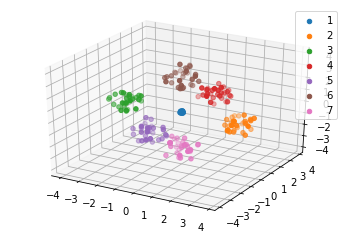

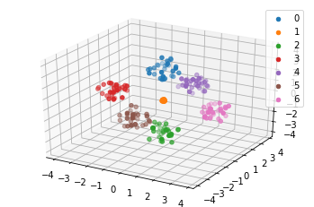

```python
group_sub1 = df_sub1.groupby(by = 'Class')
group_sub1_kmeans = df_sub1.groupby(by = 'kmeans')

fig = plt.figure()
ax_sub_origin = plt.axes(projection = '3d')
for (ele_id,ele) in group_sub1:
  ax_sub_origin.scatter3D(ele['X1'], ele['X2'],ele['X3'],label = ele_id)
plt.legend()


fig2 = plt.figure()
ax_sub_clustering = plt.axes(projection = '3d')
for (ele_id,ele) in group_sub1_kmeans:
  ax_sub_clustering.scatter(ele['X1'], ele['X2'], ele['X3'],label = ele_id)
plt.legend()

plt.show()
```

**According to the map we get manually, we can calculate acc and F1 now!**

```python
mapdict = {0:6,1:1,2:7,3:3,4:4,5:5,6:2}
```

```python
df_sub1['kmeans_relabel'] = df_sub1['kmeans'].map(mapdict)
```

```python
df_sub1['kmeans_relabel'].value_counts()
```

```
1    32
2    30
3    30
4    30
5    30
6    30
7    30
Name: kmeans_relabel, dtype: int64
```

### external validation

**metric of dataset1**

```python
from sklearn import metrics
import numpy as np
print('F1 score of this clustering model is:')
metrics.f1_score(df_sub1['Class'],df_sub1['kmeans_relabel'],average='weighted')
```

```
F1 score of this clustering model is:
```

```
1.0
```

```python
print('Accuracy score of this clustering model is:')
metrics.accuracy_score(df_sub1['Class'],df_sub1['kmeans_relabel'])
```

```
Accuracy score of this clustering model is:
```

```
1.0
```

### Data visualization process

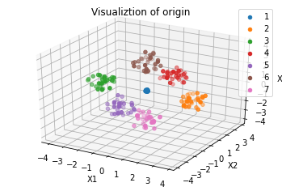

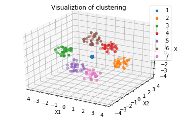

```python
group_sub1 = df_sub1.groupby(by = 'Class')
group_sub1_kmeans = df_sub1.groupby(by = 'kmeans_relabel')

fig = plt.figure()
ax_sub_origin = plt.axes(projection = '3d')
for (ele_id,ele) in group_sub1:
  ax_sub_origin.scatter3D(ele['X1'], ele['X2'],ele['X3'],label = ele_id)
ax_sub_origin.set(title = 'Visualiztion of origin')
ax_sub_origin.set_xlabel('X1')
ax_sub_origin.set_ylabel('X2')
ax_sub_origin.set_zlabel('X3')
plt.legend()

fig2 = plt.figure()
ax_sub_clustering = plt.axes(projection = '3d')
for (ele_id,ele) in group_sub1_kmeans:
  ax_sub_clustering.scatter(ele['X1'], ele['X2'], ele['X3'],label = ele_id)
ax_sub_clustering.set(title = 'Visualiztion of clustering')
ax_sub_clustering.set_xlabel('X1')
ax_sub_clustering.set_ylabel('X2')
ax_sub_clustering.set_zlabel('X3')
plt.legend()

plt.show()
```

### clustering process

**The output label of agglomerative Clustering changed every time you run the code. Please don't run this cell again**

```python
agglomer = AgglomerativeClustering(n_clusters = 7)
agglomer.fit(df_sub1.iloc[:,:-1])
df_sub1['agglomer'] = kmeans_model1.labels_
```

### mapping process

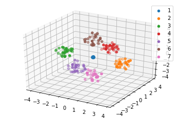

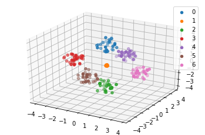

```python
group_sub1 = df_sub1.groupby(by = 'Class')
group_sub1_agglomer = df_sub1.groupby(by = 'agglomer')

fig = plt.figure()
ax_sub_origin = plt.axes(projection = '3d')
for (ele_id,ele) in group_sub1:
  ax_sub_origin.scatter3D(ele['X1'], ele['X2'],ele['X3'],label = ele_id)
plt.legend()


fig2 = plt.figure()
ax_sub_clustering = plt.axes(projection = '3d')
for (ele_id,ele) in group_sub1_agglomer:
  ax_sub_clustering.scatter(ele['X1'], ele['X2'], ele['X3'],label = ele_id)
plt.legend()

plt.show()
```

**According to the map we get manually, we can calculate acc and F1 now!**

```python
mapdict = {0:6,1:1,2:7,3:3,4:4,5:5,6:2}
df_sub1['agglomer_relabel'] = df_sub1['agglomer'].map(mapdict)
df_sub1['agglomer_relabel'].value_counts()
```

```
1    32
2    30
3    30
4    30
5    30
6    30
7    30
Name: agglomer_relabel, dtype: int64
```

### external validation

```python
print('F1 score of this clustering model is:')
metrics.f1_score(df_sub1['Class'],df_sub1['agglomer_relabel'],average='weighted')
```

```
F1 score of this clustering model is:
```

```
1.0
```

```python
metrics.accuracy_score(df_sub1['Class'],df_sub1['agglomer_relabel'])
```

```
1.0
```

### data visualiztion

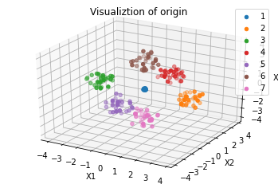

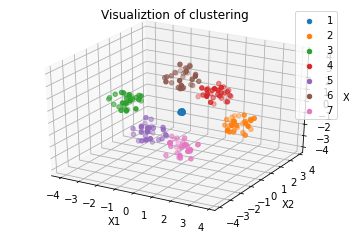

```python
group_sub1 = df_sub1.groupby(by = 'Class')
group_sub1_agglomer = df_sub1.groupby(by = 'agglomer_relabel')

fig = plt.figure()
ax_sub_origin = plt.axes(projection = '3d')
for (ele_id,ele) in group_sub1:
  ax_sub_origin.scatter3D(ele['X1'], ele['X2'],ele['X3'],label = ele_id)
ax_sub_origin.set(title = 'Visualiztion of origin')
ax_sub_origin.set_xlabel('X1')
ax_sub_origin.set_ylabel('X2')
ax_sub_origin.set_zlabel('X3')
plt.legend()

fig2 = plt.figure()
ax_sub_clustering = plt.axes(projection = '3d')
for (ele_id,ele) in group_sub1_agglomer:
  ax_sub_clustering.scatter(ele['X1'], ele['X2'], ele['X3'],label = ele_id)
ax_sub_clustering.set(title = 'Visualiztion of clustering')
ax_sub_clustering.set_xlabel('X1')
ax_sub_clustering.set_ylabel('X2')
ax_sub_clustering.set_zlabel('X3')
plt.legend()

plt.show()
```

# Dealing with Data 2

## uploading the file(s)

```python
from google.colab import files
files.upload()
```

Upload widget is only available when the cell has been executed in the current browser session. Please rerun this cell to enable.

```
Saving Data2.csv to Data2.csv
```

[output not shown]

```python
df_sub2 = pd.read_csv(r'Data2.csv').iloc[:,1:]
```

## exploreing about the data

```python
df_sub2.shape
```

```
(404, 4)
```

```python
df_sub2.head(2)
```

|  | X | Y | C | Class |
| --- | --- | --- | --- | --- |
| 0 | 3.277701 | 0.814082 | 0.326574 | 1 |
| 1 | 0.387577 | 0.176780 | 0.888046 | 1 |

```python
df_sub2['Class'].value_counts()
```

```
1    200
2    100
3    100
4      4
Name: Class, dtype: int64
```

## kmeans

1. k = 4

### clustering process

```python
kmeans_model2 = KMeans(n_clusters = 4, random_state = 886)
```

```python
kmeans_model2.fit(df_sub2.iloc[:,:-1])
```

```
KMeans(n_clusters=4, random_state=886)
```

```python
df_sub2['kmeans'] = kmeans_model2.labels_
```

### mapping process

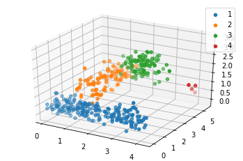

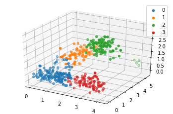

```python
group_sub2 = df_sub2.groupby(by = 'Class')
group_sub2_kmeans = df_sub2.groupby(by = 'kmeans')

fig = plt.figure()
ax_sub_origin = plt.axes(projection = '3d')
for (ele_id,ele) in group_sub2:
  ax_sub_origin.scatter3D(ele['X'], ele['Y'],ele['C'],label = ele_id)
plt.legend()


fig2 = plt.figure()
ax_sub_clustering = plt.axes(projection = '3d')
for (ele_id,ele) in group_sub2_kmeans:
  ax_sub_clustering.scatter(ele['X'], ele['Y'], ele['C'],label = ele_id)
plt.legend()

plt.show()
```

**According to the map we get manually, the matching relationship is a litter bit complex than question 1!!!!!!!**

```python
mapdict2 = {0:1,1:2,2:3,3:1}
df_sub2['kmeans_relabel'] = df_sub2['kmeans'].map(mapdict2)
```

### external validation

```python
print('F1 score of this clustering model is:')
metrics.f1_score(df_sub2['Class'],df_sub2['kmeans_relabel'],average='weighted')
```

```
F1 score of this clustering model is:
```

```
0.9315126858415265
```

```python
print('accuracy of this clustering model is:')
metrics.accuracy_score(df_sub2['Class'],df_sub2['kmeans_relabel'])
```

```
accuracy of this clustering model is:
```

```
0.9381188118811881
```

### data visualization

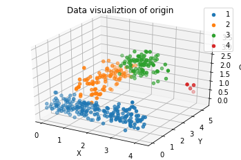

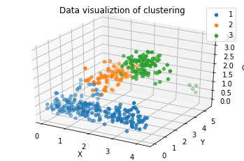

```python
group_sub2 = df_sub2.groupby(by = 'Class')
group_sub2_kmeans = df_sub2.groupby(by = 'kmeans_relabel')

fig = plt.figure()
ax_sub_origin = plt.axes(projection = '3d')
for (ele_id,ele) in group_sub2:
  ax_sub_origin.scatter3D(ele['X'], ele['Y'],ele['C'],label = ele_id)
ax_sub_origin.set_title('Data visualiztion of origin')
ax_sub_origin.set_xlabel('X')
ax_sub_origin.set_ylabel('Y')
ax_sub_origin.set_zlabel('C')
plt.legend()


fig2 = plt.figure()
ax_sub_clustering = plt.axes(projection = '3d')
for (ele_id,ele) in group_sub2_kmeans:
  ax_sub_clustering.scatter(ele['X'], ele['Y'], ele['C'],label = ele_id)
ax_sub_clustering.set_title('Data visualiztion of clustering')
ax_sub_clustering.set_xlabel('X')
ax_sub_clustering.set_ylabel('Y')
ax_sub_clustering.set_zlabel('C')
plt.legend()

plt.show()
```

## agglomer

### clustering process

**The output label of agglomerative Clustering changed every time you run the code. Please don't run this cell again**

```python
agglomer_model2 = AgglomerativeClustering(n_clusters = 4)
agglomer_model2.fit(df_sub2.iloc[:,:-1])
df_sub2['agglomer'] = agglomer_model2.labels_
```

### mapping process

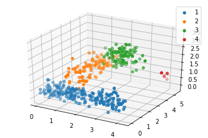

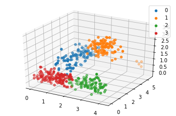

```python
group_sub2 = df_sub2.groupby(by = 'Class')
group_sub2_agglomer = df_sub2.groupby(by = 'agglomer')

fig = plt.figure()
ax_sub_origin = plt.axes(projection = '3d')
for (ele_id,ele) in group_sub2:
  ax_sub_origin.scatter3D(ele['X'], ele['Y'],ele['C'],label = ele_id)
plt.legend()


fig2 = plt.figure()
ax_sub_clustering = plt.axes(projection = '3d')
for (ele_id,ele) in group_sub2_agglomer:
  ax_sub_clustering.scatter(ele['X'], ele['Y'], ele['C'],label = ele_id)
plt.legend()

plt.show()
```

**According to the map we get manually, the matching relationship is a litter bit complex than question 1!!!!!!!**

```python
mapdict2 = {0:2,1:3,2:1,3:1}
df_sub2['agglomer_relabel'] = df_sub2['agglomer'].map(mapdict2)
```

### external validation

```python
print('F1 score of this clustering model is:')
metrics.f1_score(df_sub2['Class'],df_sub2['agglomer_relabel'],average = 'weighted')
```

```
F1 score of this clustering model is:
```

```
0.9852455833818675
```

```python
print('Accuracy of this clustering model is:')
metrics.accuracy_score(df_sub2['Class'],df_sub2['agglomer_relabel'])
```

```
Accuracy of this clustering model is:
```

```
0.9900990099009901
```

### data visualization

**The final version plot**

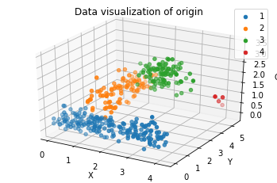

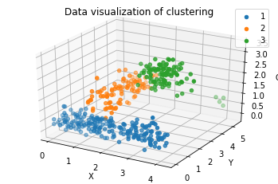

```python
group_sub2 = df_sub2.groupby(by = 'Class')
group_sub2_agglomer = df_sub2.groupby(by = 'agglomer_relabel')

fig = plt.figure()
ax_sub_origin = plt.axes(projection = '3d')
for (ele_id,ele) in group_sub2:
  ax_sub_origin.scatter3D(ele['X'], ele['Y'],ele['C'],label = ele_id)
ax_sub_origin.set_title('Data visualization of origin')
ax_sub_origin.set_xlabel('X')
ax_sub_origin.set_ylabel('Y')
ax_sub_origin.set_zlabel('C')
plt.legend()


fig2 = plt.figure()
ax_sub_clustering = plt.axes(projection = '3d')
for (ele_id,ele) in group_sub2_agglomer:
  ax_sub_clustering.scatter(ele['X'], ele['Y'], ele['C'],label = ele_id)
ax_sub_clustering.set_title('Data visualization of clustering')
ax_sub_clustering.set_xlabel('X')
ax_sub_clustering.set_ylabel('Y')
ax_sub_clustering.set_zlabel('C')
plt.legend()

plt.show()
```

# Dealing with Data 3

## uploading the file(s)

```python
from google.colab import files
files.upload()
df_sub3 = pd.read_csv(r'Data3.csv').iloc[:,1:]
```

Upload widget is only available when the cell has been executed in the current browser session. Please rerun this cell to enable.

```
Saving Data3.csv to Data3.csv
```

## exploreing about the data

```python
df_sub3.shape
```

```
(400, 4)
```

```python
df_sub3.head(2)
```

|  | X1 | X2 | X3 | Class |
| --- | --- | --- | --- | --- |
| 0 | 1.295428 | 0.050829 | -0.385217 | 1 |
| 1 | 1.409178 | -0.035191 | -0.251980 | 1 |

```python
df_sub3['Class'].value_counts()
```

```
1    100
2    100
3    100
4    100
Name: Class, dtype: int64
```

## kmeans

1. k = 4

### clustering process

```python
kmeans_model3 = KMeans(n_clusters = 4,random_state = 70138750)
kmeans_model3.fit(df_sub3.iloc[:,:-1])
df_sub3['kmeans'] = kmeans_model3.labels_
```

### mapping process

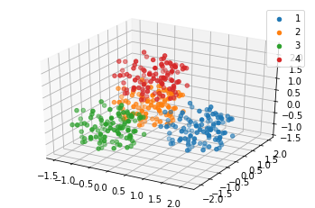

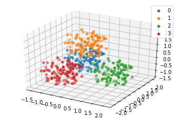

```python
group_sub3 = df_sub3.groupby(by = 'Class')
group_sub3_kmeans = df_sub3.groupby(by = 'kmeans')

fig = plt.figure()
ax_sub_origin = plt.axes(projection = '3d')
for (ele_id,ele) in group_sub3:
  ax_sub_origin.scatter3D(ele['X1'], ele['X2'],ele['X3'],label = ele_id)
plt.legend()


fig2 = plt.figure()
ax_sub_clustering = plt.axes(projection = '3d')
for (ele_id,ele) in group_sub3_kmeans:
  ax_sub_clustering.scatter(ele['X1'], ele['X2'], ele['X3'],label = ele_id)
plt.legend()

plt.show()
```

**According to the map we get manually, we can calculate acc and F1 now!**

```python
mapdict = {0:2,1:4,2:1,3:3}
df_sub3['kmeans_relabel'] = df_sub3['kmeans'].map(mapdict)
df_sub3['kmeans_relabel'].value_counts()
```

```
1    100
2    100
3    100
4    100
Name: kmeans_relabel, dtype: int64
```

### external validation

```python
print('F1 score of this clustering model is:')
metrics.f1_score(df_sub3['Class'],df_sub3['kmeans_relabel'],average = 'weighted')
```

```
F1 score of this clustering model is:
```

```
1.0
```

```python
print('accuracy score of this clustering model is:')
metrics.accuracy_score(df_sub3['Class'],df_sub3['kmeans_relabel'])
```

```
accuracy score of this clustering model is:
```

```
1.0
```

### data visualization

**final plot**

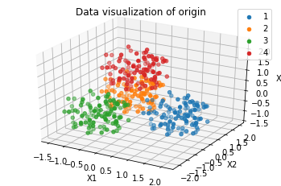

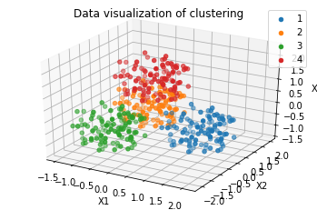

```python
group_sub3 = df_sub3.groupby(by = 'Class')
group_sub3_kmeans = df_sub3.groupby(by = 'kmeans_relabel')

fig = plt.figure()
ax_sub_origin = plt.axes(projection = '3d')
for (ele_id,ele) in group_sub3:
  ax_sub_origin.scatter3D(ele['X1'], ele['X2'],ele['X3'],label = ele_id)
ax_sub_origin.set_title('Data visualization of origin')
ax_sub_origin.set_xlabel('X1')
ax_sub_origin.set_ylabel('X2')
ax_sub_origin.set_zlabel('X3')
plt.legend()


fig2 = plt.figure()
ax_sub_clustering = plt.axes(projection = '3d')
for (ele_id,ele) in group_sub3_kmeans:
  ax_sub_clustering.scatter(ele['X1'], ele['X2'], ele['X3'],label = ele_id)
ax_sub_clustering.set_title('Data visualization of clustering')
ax_sub_clustering.set_xlabel('X1')
ax_sub_clustering.set_ylabel('X2')
ax_sub_clustering.set_zlabel('X3')
plt.legend()

plt.show()
```

## hierarchical

### clustering process

**The output label of agglomerative Clustering changed every time you run the code. Please don't run this cell again**

```python
agglomer_model3 = AgglomerativeClustering(n_clusters = 4)
agglomer_model3.fit(df_sub3.iloc[:,:-1])
df_sub3['agglomer'] = agglomer_model3.labels_
```

### mapping process

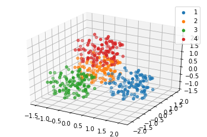

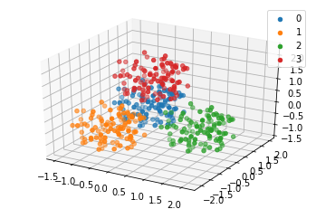

```python
group_sub3 = df_sub3.groupby(by = 'Class')
group_sub3_agglomer = df_sub3.groupby(by = 'agglomer')

fig = plt.figure()
ax_sub_origin = plt.axes(projection = '3d')
for (ele_id,ele) in group_sub3:
  ax_sub_origin.scatter3D(ele['X1'], ele['X2'],ele['X3'],label = ele_id)
plt.legend()


fig2 = plt.figure()
ax_sub_clustering = plt.axes(projection = '3d')
for (ele_id,ele) in group_sub3_agglomer:
  ax_sub_clustering.scatter(ele['X1'], ele['X2'], ele['X3'],label = ele_id)
plt.legend()

plt.show()
```

**According to the map we get manually, we can calculate acc and F1 now!**

```python
mapdict = {0:2,1:3,2:1,3:4}
df_sub3['agglomer_relabel'] = df_sub3['agglomer'].map(mapdict)
df_sub3['agglomer_relabel'].value_counts()
```

```
1    100
2    100
3    100
4    100
Name: agglomer_relabel, dtype: int64
```

### external validation

```python
print('F1 score of this clustering model is:')
metrics.f1_score(df_sub3['Class'],df_sub3['agglomer_relabel'],average = 'weighted')
```

```
F1 score of this clustering model is:
```

```
1.0
```

```python
print('Accuracy of this clustering model is:')
metrics.accuracy_score(df_sub3['Class'],df_sub3['agglomer_relabel'])
```

```
Accuracy of this clustering model is:
```

```
1.0
```

### data visualization

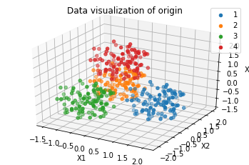

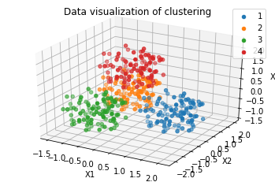

```python
group_sub3 = df_sub3.groupby(by = 'Class')
group_sub3_agglomer = df_sub3.groupby(by = 'agglomer_relabel')

fig = plt.figure()
ax_sub_origin = plt.axes(projection = '3d')
for (ele_id,ele) in group_sub3:
  ax_sub_origin.scatter3D(ele['X1'], ele['X2'],ele['X3'],label = ele_id)
ax_sub_origin.set_title('Data visualization of origin')
ax_sub_origin.set_xlabel('X1')
ax_sub_origin.set_ylabel('X2')
ax_sub_origin.set_zlabel('X3')
plt.legend()


fig2 = plt.figure()
ax_sub_clustering = plt.axes(projection = '3d')
for (ele_id,ele) in group_sub3_agglomer:
  ax_sub_clustering.scatter(ele['X1'], ele['X2'], ele['X3'],label = ele_id)
ax_sub_clustering.set_title('Data visualization of clustering')
ax_sub_clustering.set_xlabel('X1')
ax_sub_clustering.set_ylabel('X2')
ax_sub_clustering.set_zlabel('X3')
plt.legend()

plt.show()
```

# Dealing with Data4

## uploading the data

```python
from google.colab import files
files.upload()
df_sub4 = pd.read_csv(r'Data4.csv').iloc[:,1:]
```

Upload widget is only available when the cell has been executed in the current browser session. Please rerun this cell to enable.

```
Saving Data4.csv to Data4.csv
```

## exploring the data

```python
df_sub4.shape
```

```
(1000, 4)
```

```python
df_sub4.head(2)
```

|  | X1 | X2 | X3 | Class |
| --- | --- | --- | --- | --- |
| 0 | -0.453 | -0.891 | 0.0230 | 1 |
| 1 | 0.653 | -0.846 | 0.0211 | 1 |

```python
df_sub4['Class'].value_counts()
```

```
1    500
2    500
Name: Class, dtype: int64
```

1. k = 2

## kmeans

### clustering process

```python
kmeans_model4 = KMeans(n_clusters = 2, random_state = 572345723)
kmeans_model4.fit(df_sub4.iloc[:,:-1])
df_sub4['kmeans'] = kmeans_model4.labels_
```

### mapping process

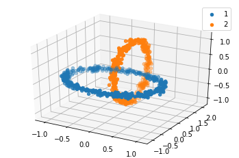

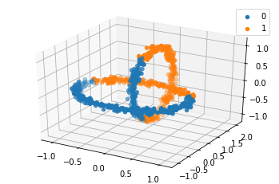

```python
group_sub4 = df_sub4.groupby(by = 'Class')
group_sub4_kmeans = df_sub4.groupby(by = 'kmeans')

fig = plt.figure()
ax_sub_origin = plt.axes(projection = '3d')
for (ele_id,ele) in group_sub4:
  ax_sub_origin.scatter3D(ele['X1'], ele['X2'],ele['X3'],label = ele_id)
plt.legend()


fig2 = plt.figure()
ax_sub_clustering = plt.axes(projection = '3d')
for (ele_id,ele) in group_sub4_kmeans:
  ax_sub_clustering.scatter(ele['X1'], ele['X2'], ele['X3'],label = ele_id)
plt.legend()

plt.show()
```

**According to the map we get manually, we can calculate acc and F1 now!**

```python
mapdict = {0:1,1:2}
df_sub4['kmeans_relabel'] = df_sub4['kmeans'].map(mapdict)
df_sub4['kmeans_relabel'].value_counts()
```

```
1    501
2    499
Name: kmeans_relabel, dtype: int64
```

### external validation

```python
print('F1 score of this clustering model is:')
metrics.f1_score(df_sub4['Class'],df_sub4['kmeans_relabel'],average = 'weighted')
```

```
F1 score of this clustering model is:
```

```
0.6529996529996529
```

```python
print('accuracy of this clustering model is:')
metrics.accuracy_score(df_sub4['Class'],df_sub4['kmeans_relabel'])
```

```
accuracy of this clustering model is:
```

```
0.653
```

### data visualization

**final plot**

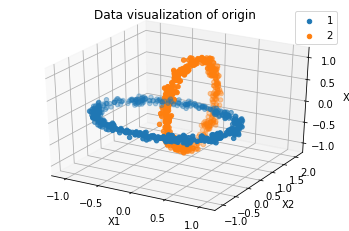

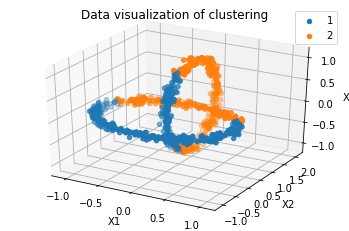

```python
group_sub4 = df_sub4.groupby(by = 'Class')
group_sub4_kmeans = df_sub4.groupby(by = 'kmeans_relabel')

fig = plt.figure()
ax_sub_origin = plt.axes(projection = '3d')
for (ele_id,ele) in group_sub4:
  ax_sub_origin.scatter3D(ele['X1'], ele['X2'],ele['X3'],label = ele_id)
ax_sub_origin.set_title('Data visualization of origin')
ax_sub_origin.set_xlabel('X1')
ax_sub_origin.set_ylabel('X2')
ax_sub_origin.set_zlabel('X3')
plt.legend()


fig2 = plt.figure()
ax_sub_clustering = plt.axes(projection = '3d')
for (ele_id,ele) in group_sub4_kmeans:
  ax_sub_clustering.scatter(ele['X1'], ele['X2'], ele['X3'],label = ele_id)
ax_sub_clustering.set_title('Data visualization of clustering')
ax_sub_clustering.set_xlabel('X1')
ax_sub_clustering.set_ylabel('X2')
ax_sub_clustering.set_zlabel('X3')
plt.legend()

plt.show()
```

## hierarchical

### clustering process

```python
agglomer_model4 = AgglomerativeClustering(n_clusters = 2)
agglomer_model4.fit(df_sub4.iloc[:,:-1])
df_sub4['agglomer'] = agglomer_model4.labels_
```

### mapping process

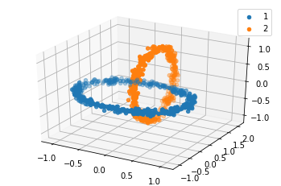

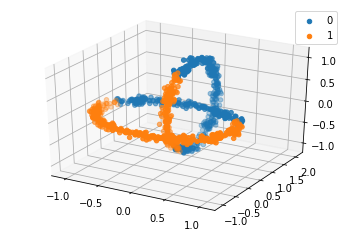

```python
group_sub4 = df_sub4.groupby(by = 'Class')
group_sub4_agglomer = df_sub4.groupby(by = 'agglomer')

fig = plt.figure()
ax_sub_origin = plt.axes(projection = '3d')
for (ele_id,ele) in group_sub4:
  ax_sub_origin.scatter3D(ele['X1'], ele['X2'],ele['X3'],label = ele_id)
plt.legend()


fig2 = plt.figure()
ax_sub_clustering = plt.axes(projection = '3d')
for (ele_id,ele) in group_sub4_agglomer:
  ax_sub_clustering.scatter(ele['X1'], ele['X2'], ele['X3'],label = ele_id)
plt.legend()

plt.show()
```

**According to the map we get manually, we can calculate acc and F1 now!**

```python
mapdict = {1:1,0:2}
df_sub4['agglomer_relabel'] = df_sub4['agglomer'].map(mapdict)
df_sub4['agglomer_relabel'].value_counts()
```

```
1    501
2    499
Name: agglomer_relabel, dtype: int64
```

```python
print('F1 score of this clustering model is:')
metrics.f1_score(df_sub4['Class'],df_sub4['agglomer_relabel'], average = 'weighted')
```

```
F1 score of this clustering model is:
```

```
0.6529996529996529
```

```python
print('accuracy of this clustering model is:')
metrics.accuracy_score(df_sub4['Class'],df_sub4['agglomer_relabel'])
```

```
accuracy of this clustering model is:
```

```
0.653
```

### data visualization

**final plot**

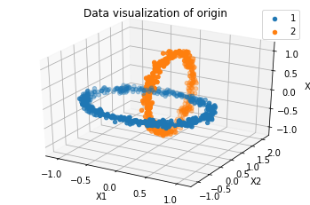

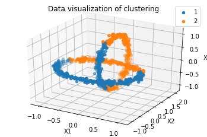

```python
group_sub4 = df_sub4.groupby(by = 'Class')
group_sub4_agglomer = df_sub4.groupby(by = 'agglomer_relabel')

fig = plt.figure()
ax_sub_origin = plt.axes(projection = '3d')
for (ele_id,ele) in group_sub4:
  ax_sub_origin.scatter3D(ele['X1'], ele['X2'],ele['X3'],label = ele_id)
ax_sub_origin.set_title('Data visualization of origin')
ax_sub_origin.set_xlabel('X1')
ax_sub_origin.set_ylabel('X2')
ax_sub_origin.set_zlabel('X3')
plt.legend()


fig2 = plt.figure()
ax_sub_clustering = plt.axes(projection = '3d')
for (ele_id,ele) in group_sub4_agglomer:
  ax_sub_clustering.scatter(ele['X1'], ele['X2'], ele['X3'],label = ele_id)
ax_sub_clustering.set_title('Data visualization of clustering')
ax_sub_clustering.set_xlabel('X1')
ax_sub_clustering.set_ylabel('X2')
ax_sub_clustering.set_zlabel('X3')
plt.legend()

plt.show()
```